# Homework20190925

Khó͘ gē choân

#9.4 a.母體是全部可以搜集資料的單位，樣本則是從母體中進行隨機抽樣後的單位，也就是實際上被我們統計調查到的人。在這個案例裡面，母體是全部的成人男性，樣本是22071個男性內科醫生。  
b.

因為服用安慰劑的內科醫生是從22071個男性內科醫生裡面隨機選出的，所以服用安慰劑後的心臟病發的比例0.017是樣本統計量。母體參數會是全部服用安慰劑的男性。

#9.52

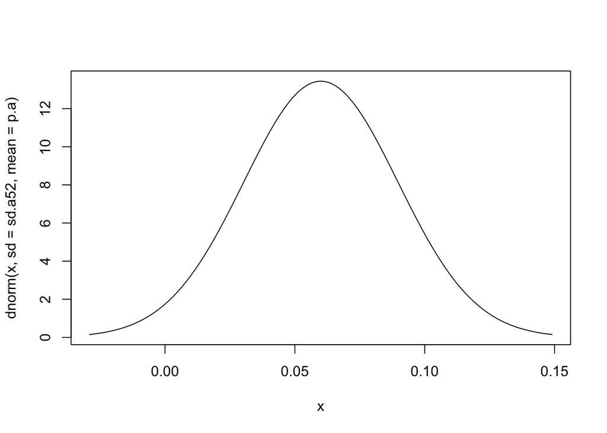

```r
#a.求差距的樣本分佈
p.a1=0.36
p.a2=0.3

p.a=p.a1-p.a2

sd.a52=sqrt((p.a1*(1-p.a1))/500+(p.a2*(1-p.a2))/500)

curve(dnorm(x,sd=sd.a52, mean=p.a), p.a-3*sd.a52, p.a+3*sd.a52)
```

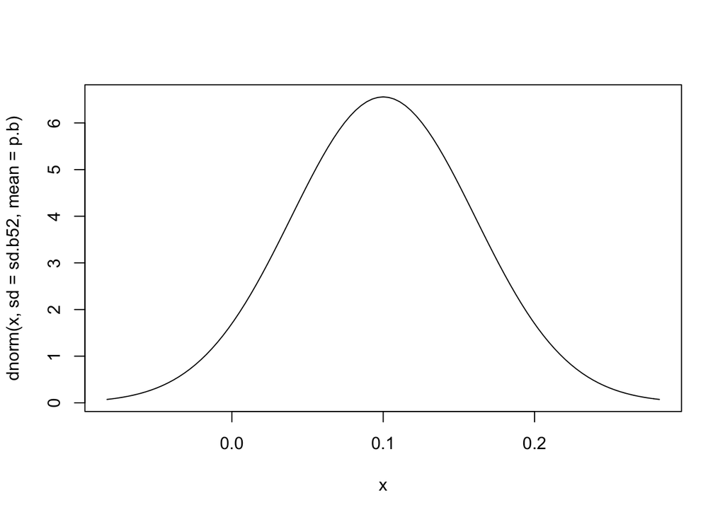

```r
#b

p.b1=0.3
p.b2=0.2

p.b=0.1

sd.b52=sqrt((p.b1*(1-p.b1)/100)+(p.b2*(1-p.b2)/100))

curve(dnorm(x,sd=sd.b52, mean=p.b), p.b-3*sd.b52, p.b+3*sd.b52)
```

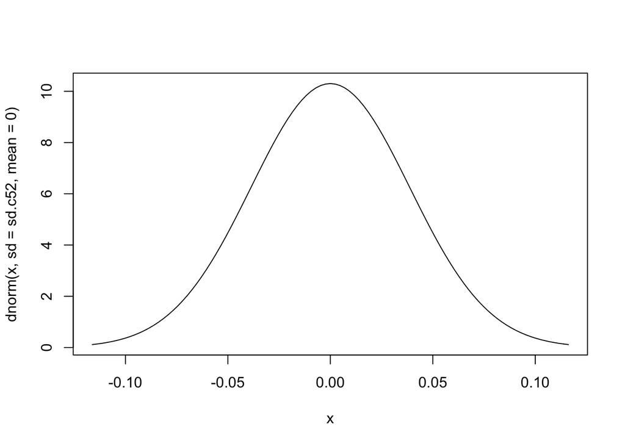

```r
#c

p.c1=0.4
p.c2=0.4
p.c=0
sd.c52=sqrt((p.c1*(1-p.c1)/200)+(p.c2*(1-p.c2)/800))




curve(dnorm(x,sd=sd.c52, mean=0), -3*sd.c52, 3*sd.c52)
```

#9.64